# Francis_QR

$σ_1$ and $σ_2$ are conjugate pair

$H_0-σ_1I = Q_1R_1,$

$H_1 = R_1Q_1 + σ_1I,$

$H_1-σ_2I = Q_2R_2,$

$H_2 = R_2Q_2 + σ_2I.$

then we can conclude:

$H_1-σ_2I = Q_2R_2$

$R_1Q_1 + σ_1I-σ_2I = Q_2R_2$

multiply $Q_1$ to the left of the equility and $R_1$ to the right:

$Q_1R_1Q_1R_1 + (σ_1-σ_2)Q_1R_1 = Q_1Q_2R_2R_1$

$[Q_1R_1 + (σ_1-σ_2)I]Q_1R_1 = Q_1Q_2R_2R_1$

$[H_0-σ_1I + (σ_1-σ_2)I]Q_1R_1 = Q_1Q_2R_2R_1$

$(H_0-σ_2I)(H_0-σ_1I) = Q_1Q_2R_2R_1$

$H_0^2-(σ_1+σ_2)H_0+σ_2σ_1I=Q_1Q_2R_2R_1$

since $σ_1$ and $σ_2$ are conjugate pair:

$σ_1+σ_2=2Re(σ)$

$σ_2σ_1=|σ|^2$

$H_0^2-(σ_1+σ_2)H_0+σ_2σ_1I=Q_1Q_2R_2R_1$

$H_0^2-2Re(σ)H_0+|σ|^2I=Q_1Q_2R_2R_1$

let matrix $M=Q_1Q_2R_2R_1$, matrix $Z=Q_1Q_2$ and $R=R_2R_1$

we can know $Z,R$ is the QR decomposition of $M$

$H_2 = R_2Q_2 + σ_2I$

multiply $Q_2^TQ_2$ to the right of above equility

$H_2 = Q_2^TQ_2R_2Q_2 + σ_2Q_2^TQ_2$

$=Q_2^T(Q_2R_2+σ_2I)Q_2$

$=Q_2^TH_1Q_2$

$=Q_2^T(R_1Q_1 + σ_1I)Q_2$

multiply $Q_1^TQ_1$ to the right side of equility $R_1Q_1 + σ_1I$

$H_2=Q_2^T(Q_1^TQ_1R_1Q_1 + σ_1Q_1^TQ_1)Q_2$

$=Q_2^TQ_1^T(Q_1R_1 + σ_1I)Q_1Q_2$

$=Q_2^TQ_1^TH_0Q_1Q_2$

$=(Q_1Q_2)^TH_0Q_1Q_2$

$=Z^TH_0Z$

we can know that $H_2$ is similar to $H_0$, which means they have the same eigenvalues and eigenvectors.

How to construct $H_2$ with $H_0$?

--> we need to obtain $Z=Q_1Q_2$

How to obtain $Z$?

-->from QR decomposition of matrix $M$:

(a) build $M$ from $H_0^2-2Re(σ)H_0+|σ|^2I$

only the first 3 elements of the first column of matrix 𝑀 is nonempty

(b) compute QR decomposition of M

(c) set $H_2=Z^TH_0Z$

obviously, (a) and (b) are both expensive!

-->We can apply "the implicit Q theorem" to find matrix $Z_1$ to replace matrix $Z$ if the first columns of matrix $Z_1$ and $Z$ are the same and $h^=Z_1^TH_0Z_1$ is Hessenberg matrix.

How to find matrix $Z_1$?

1. Let $P_0$ be the Householder reflector with:

$P_0^TMe_1=P_0^T(H_0^2-2Re(σ)H_0+|σ|^2I)e_1=αe_1$

($α$ is the norm of the first column of M)

since only the first 3 elements of the first column of matrix $M$ is nonempty, the structure of $P_0$ is like this:

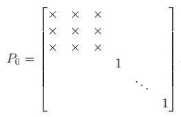

compute $H_0^\prime=P_0^TH_0P_0$

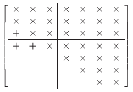

obviously, $H_0^\prime$ is not Hessenberg matrix, now we start to reduce $H_0^\prime$ to Hessenberg form by Householder transformation.

1. let $P_1$ be the Householder reflector for $H_0^\prime[2:,1]$

compute $H_0^{\prime\prime}=P_1^T$$H_0^\prime$$P_1$

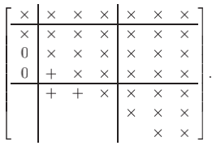

let $P_2$ be the Householder reflector for $H_0^{\prime\prime}[3:,2]$

compute $H_0^{\prime\prime\prime}=P_2^T$$H_0^{\prime\prime}$$P_2$

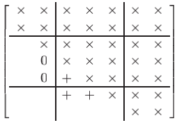

...

let $P_{n-2}$ be the Given Rotation for $H_0^{\prime...\prime}[n-1:,n-2]$

compute $H_0^{\prime...\prime\prime}=P_{n-2}^T$$H_0^{\prime...\prime}$$P_{n-2}$

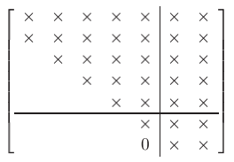

1. $H_0^{\prime...\prime\prime}=(P_0P_1...P_{n-2})^TH_0(P_0P_1...P_{n-2})$

according to the special structure of $P_0,P_1,...,P_{n-2}$, it's easy to know:

$(P_0P_1...P_{n-2})e_1=P_0e_1=\frac{Me_1}{α}$

1. since the first column of Q in QR decomposition is equal to the normalized first column of original matrix. we can conclude that $\frac{Me_1}{α}=Ze_1$
2. let $Z_1=P_0P_1...P_{n-2}$

it's obviously that $Z_1e_1=(P_0P_1...P_{n-2})e_1=Ze_1$ and $h=H_0^{\prime...\prime\prime}=Z_1^TH_0Z_1$ is Hessenberg matrix

according to "the implicit Q theorem", $H_2$ and $h$ are "essentially equal"

-->instead of building $H_2$, we can build $h$.

Now we can compute the eigenvalue when $h$ is converging:

1. when $h_{n,n-1}$ is converging(close to zero), $h_{n,n}$ is the real number eigenvalue. In the next iteration, only compute $h_{[:n-1,:n-1]}$(discard the last row and last column);
2. when $h_{n-1,n-2}$ is converging , the conjugate pair eigenvalue of the 2x2 matrix at the bottom right are the complex number eigenvalues. In the next iteration, only compute $h_{[:n-2,:n-2]}$(discard the last 2 rows and last 2 columns)